# ATTENTION IS ALL YOU NEED

A Foray Into Transformers

Marco R. Steenbergen

steenbergen@ipz.uzh.ch

University of Zurich

July 31, 2026

# Word Embeddings

## Why Numbers?

- Machine learning algorithms expect **numeric inputs**, but words are symbols that carry no inherent numeric value.
- Before we can model text, we must convert words into numbers.
- The catch: we want a conversion that **preserves meaning**, so that words used in similar ways end up with similar numbers.
- The result of such a conversion is called an **embedding**.

## The Naive Fix Fails

- Why not just assign each word an integer (e.g., “cat” = 1, “dog” = 2, …)?
  - This invents an ordering that does not exist and implies “cat” $<$ “dog”.
- Why not use **one-hot vectors** — a 1 in the word’s slot and 0 everywhere else?
  - No false ordering, but the vectors are huge, sparse, and mutually **orthogonal**.
  - Every pair of words is then equally dissimilar: all meaning is lost.
- We want **dense, low-dimensional** vectors in which similar words sit close together $\rightarrow$ *learned* embeddings.

## The Intuition

- Imagine two phrases:
  1. “Barbie is great.”
  2. “Oppenheimer is great.”
- Let us use a word to **predict the next word** in the sentence.
  - The weight assigned to a word becomes its embedding.
  - We choose the weights so that prediction is optimized.
- Words can have multiple meanings:
  - “great” could mean *wonderful*.
  - It could also be sarcastic, as in “Great, now it started raining.”
- Words with similar meanings should receive similar numerical values.

## The Approach

- Inputs are unique words that can be **active** (1) if they are our focus or **inactive** (0) if they are not.
- We add as many hidden nodes as we want embedding dimensions.
- We then use the embeddings to predict the next word. For instance:
  - Input: Oppenheimer = 1
  - Target: is
- The weights associated with each input word **are** the embeddings.
- There are no biases.

## Architecture

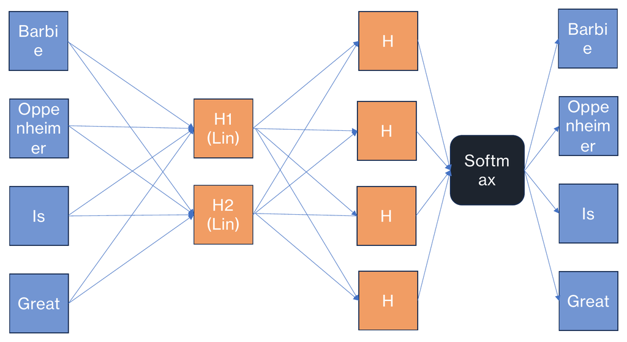

## A Worked Example

- Imagine $w_{11} = 0.5$ and $w_{21} = -0.1$. When Barbie = 1, then $H_1 = 0.5$ and $H_2 = -0.1$.
- Imagine the connections from $H_1$ to the softmax layer are $0.1, 0.2, 0.5, 0.2$.
- Imagine the connections from $H_2$ to the softmax layer are $0.2, -0.2, 0.2, -0.3$.
- Then:
  - $P(\text{Barbie}) = 0.226$
  - $P(\text{Oppenheimer}) = 0.248$
  - $\mathbf{P(\text{Is}) = 0.276}$
  - $P(\text{Great}) = 0.250$

## Final Embeddings

| Word | $H_1$ | $H_2$ |
| --- | --- | --- |
| Barbie | 2.02 | 1.98 |
| Oppenheimer | 1.73 | 1.99 |
| Is | -2.17 | 2.48 |
| Great | -2.13 | -2.23 |

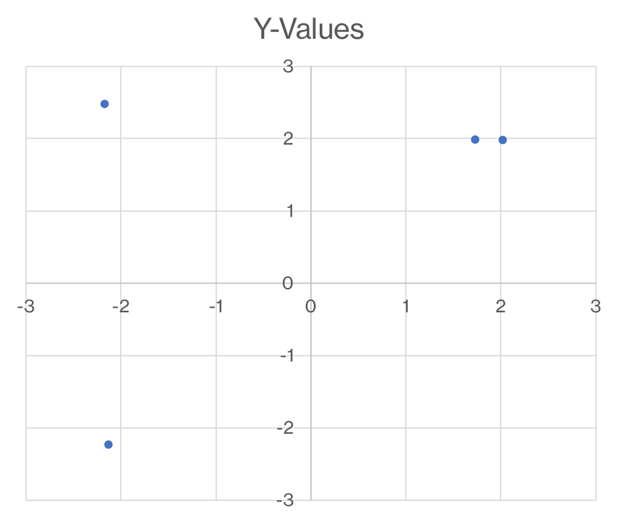

Barbie and Oppenheimer (top right) sit close together; “Is” and “Great” end up far away.

## Measuring Similarity

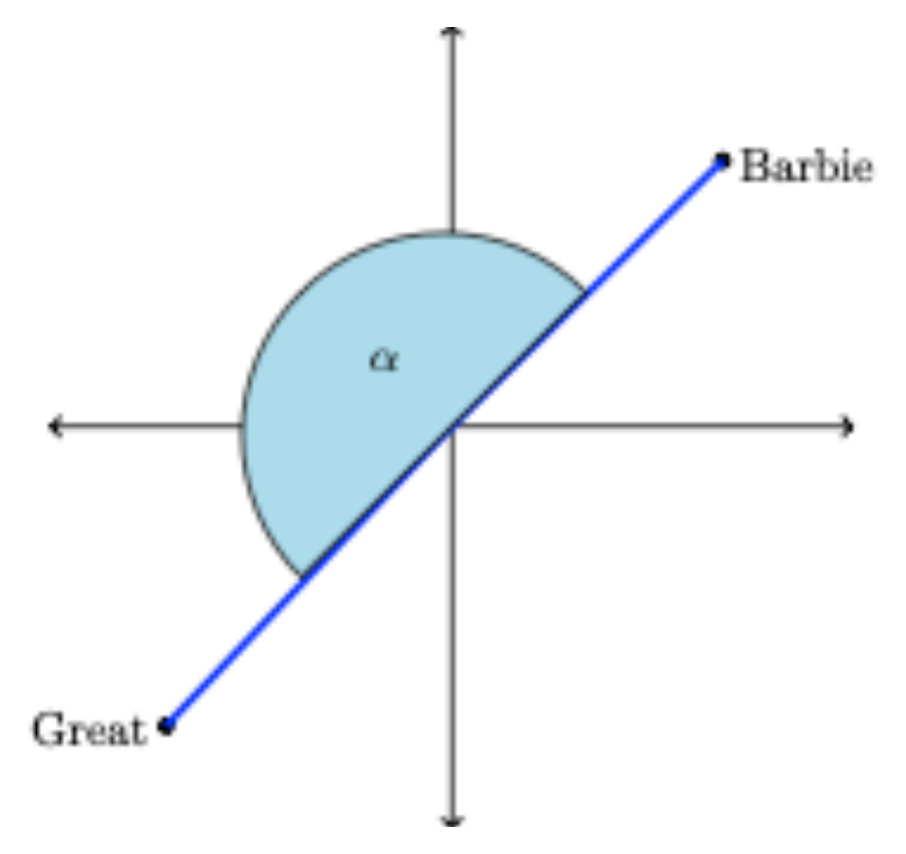

- Semantic similarity in the latent space is measured using **cosine similarity**.
- For example, the cosine similarity between “Barbie” and “Great” is roughly $\cos 180^\circ = -1$.
- It always lies between $-1$ and $1$, and is computed as

  $$\cos \alpha = \frac{\boldsymbol{a} \cdot \boldsymbol{b}}{\|\boldsymbol{a}\|\,\|\boldsymbol{b}\|}$$
- **Foreshadowing:** this dot product between vectors is exactly the machinery that will drive *attention* later on.

## In Reality …

- We train on vastly more sentences, e.g., all of Wikipedia.
- We include many more hidden nodes (e.g., 100).
- Moreover, we take more context into account.

# Word2Vec

## Adding Context

- Word2Vec (Mikolov et al. 2013) adds more context to the embeddings.
- Word2Vec, for instance, uses
  - **Continuous bag of words** (CBOW) — use the surrounding words and predict what is in the middle.
  - **Skip-gram** — use the word in the middle to predict the surrounding words.

## Two Architectures

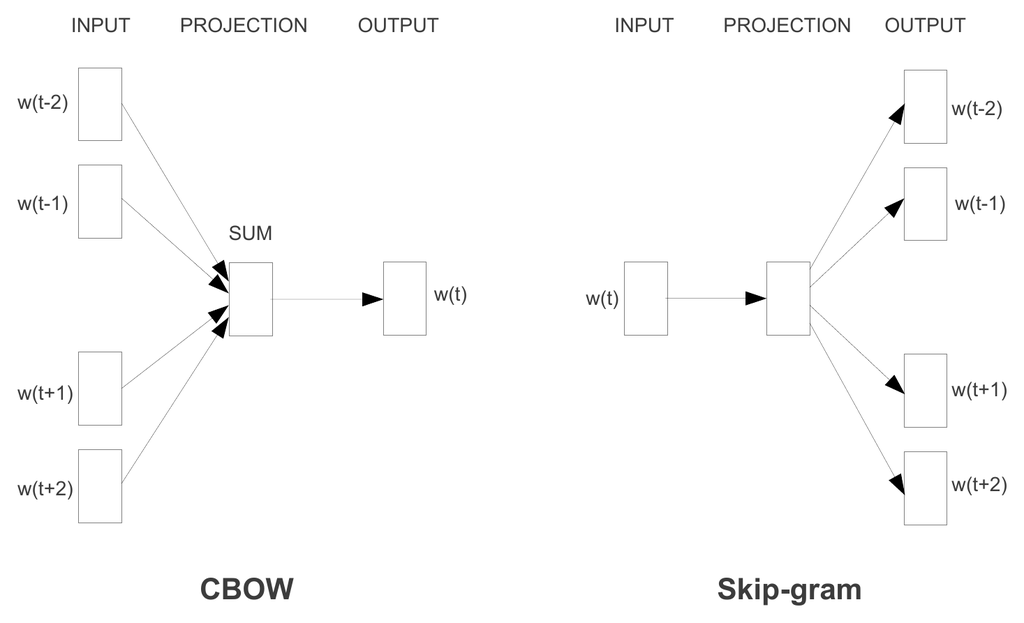

## Estimation Demands

- Word2Vec might have access to about 3 million words and phrases.
- With 100 hidden nodes, this could result in as many as 600 million weights!
- Of course, only one word will be set to 1 (unless one uses a continuous bag of words), so that eliminates close to 300 million weights going out from the words on the left side of the model.
- Still, the demands seem staggering.

## Sampling Strategies

### Subsampling

- Imagine the word pair (the, woman).
- How much information does the article “the” provide about “woman”? It is used with so many words that the answer is very little.
- Maybe we should not sample “the” very often at all $\rightarrow$ subsampling.
- We sample words less the more frequently they occur, ensuring their probability is not exactly 0.

### Negative Sampling

- Each training sample updates only a small percentage of the weights.
- We do this by dropping a large fraction of the target words.
- In (evil, woman) only “woman” is set to 1 — the target. All other potential targets are set to 0.
- We randomly select just a small fraction (2–20) of those negative words during training.

# GloVe

## Global Vectors

- GloVe = global vectors for word representation (Pennington et al. 2014).
- It expands on Word2Vec by taking even more of the context into consideration.
- Its building block is the **count matrix**, which captures how often words co-occur.

## The Count Matrix

- I favor equality.
- I favor gay marriage.

Window = 1

[output not shown]

## Notation

- $x_{ij}$ = the number of times word $j$ occurs in the context of word $i$.
- $x_{j \mid i}$ = the number of times word $j$ occurs given that word $i$ occurred as well.

## The Crux

| Prob & Ratio | $k =$ Solid | $k =$ Gas | $k =$ Water | $k =$ Fashion |
| --- | --- | --- | --- | --- |
| $P(k \mid ice)$ | High | Low | High | Low |
| $P(k \mid steam)$ | Low | High | High | Low |
| Ratio | $> 1$ | $< 1$ | $\approx 1$ | $\approx 1$ |

- We focus on the ratio

  $$\frac{P(k \mid i)}{P(k \mid j)}$$
- Here $k$ is a context word.
- Two related words have a much higher conditional probability than two unrelated words.

## Loss Function

- We set a linear function with weights and biases that optimize the log-frequency of words.
- We add a weight $f(x_{ij})$ that limits the impact of very frequent co-occurrences.
- The weights become the embeddings.

$$\text{Loss} = \sum_{i,j} f(x_{ij}) \left( \boldsymbol{w}_i^\top \boldsymbol{w}_j + b_i + b_j - \ln(x_{ij}) \right)^2$$

# Motivation

## Rich Embeddings

- We have just seen how Word2Vec and GloVe generate embeddings by considering the context of a target word.
- But two limitations remain:
  - Each word receives a *single, static* vector — “great” has one embedding whether it means *wonderful* or *sarcastic*.
  - The context is still limited to a few surrounding words.
- What if we could take in a lot more context, e.g., all of a speech, law, or novel — and let a word’s vector *change* with that context?

## A Long Journey with a Happy End

- It turns out that bringing in context is not easy, especially not when we try to use distal tokens to predict what is now.
- Early efforts included
  - Recurrent neural networks.
  - Long short term memory.
- Neither performed very well.
- Finally, Vaswani et al. (2017) developed an elegant solution that has become the backbone of modern-day **transformers** such as BERT.

# Recurrent Neural Networks

## Mimicking Autoregressive Time Series

- Consider the following sentence:

  > The shrewd politician struck a major deal with her opponents.
- We want to take into account how the first word continues to affect the last one.
- We could mimic an AR(1) process:
  - “The” $\rightarrow$ “shrewd” $\rightarrow$ “politician” $\rightarrow \cdots \rightarrow$ “her” $\rightarrow$ “opponents”
- OK, but we want to build this into a neural network to get embeddings.

## We Have a Tool

- Might this not be an excellent candidate for a **recurrent neural network** or RNN (Elman 1990)?
- RNNs contain feedback loops have **memory** on the hidden states, which is exactly what we need.
- They were developed for sequential data such as text or audio.

## What Does RNN Look Like?

[figure not shown]

**Source:** Goodfellow et al. (2016), 373.

## How Does That Help with Text?

[output not shown]

In theory, the word “The” is carried forward because it flows into $h_1$, which flows into $h_2$, etc. The same holds true for later words and their subsequent effects.

## Numeric Example

- Setup
- Setup Cont’d
- Step 1
- Step 2
- Interpretation

Imagine a tiny RNN with

- 2D word embeddings
- 2D hidden states
- No bias
- A $\tanh$ activation
- Let $x_1^\top = [1,0]$ and $x_2^\top = [0,1]$ for illustrating the first two words.
- Assume $h_0^\top = [0,0]$.
- Let

  $$W_x = \begin{bmatrix} 1 & 1 \\ 1 & -1 \end{bmatrix} \ \text{and} \ W_h = \begin{bmatrix} 0.5 & 0 \\ 0 & 0.5 \end{bmatrix}$$
- We update using $h_t = \tanh(W_x x_t + W_h h_{t-1})$.

$$h_1 = \tanh \left( \begin{bmatrix} 1 & 1 \\ 1 & -1 \end{bmatrix} \begin{bmatrix} 1 \\ 0 \end{bmatrix} + \begin{bmatrix} 0.5 & 0 \\ 0 & 0.5 \end{bmatrix} \begin{bmatrix} 0 \\ 0 \end{bmatrix} \right) \approx \begin{bmatrix} 0.76 \\ 0.76 \end{bmatrix}$$

$$h_2 = \tanh \left( \begin{bmatrix} 1 & 1 \\ 1 & -1 \end{bmatrix} \begin{bmatrix} 0 \\ 1 \end{bmatrix} + \begin{bmatrix} 0.5 & 0 \\ 0 & 0.5 \end{bmatrix} \begin{bmatrix} 0.76 \\ 0.76 \end{bmatrix} \right) \approx \begin{bmatrix} 0.88 \\ -0.55 \end{bmatrix}$$

[output not shown]

## Trouble in Paradise

- Hochreiter (1991) documented the problem of **vanishing gradients** in RNNs.
- That is, the gradients become vanishingly smallas we engage in backpropagation through time.
- This has two downsides:
  1. Backpropagation frequently fails.
  2. Even if it succeeds, it is not clear how much the distal past still matters for the current word (memory loss).

## Why Vanishing Gradients Happen

- For simplicity, let $h_t = W_h h_{t-1}$.
- We define a loss function $L = \ell(h_T)$.
- We seek to update the weights and for that we need

  $$\frac{\partial L}{\partial W_h} = \sum_{t=1}^T \frac{\partial L}{\partial h_t} \cdot \frac{\partial h_t}{\partial W_h}$$
- However $\partial h_t/\partial W_h = h_{t-1}^\top \otimes I$.
- Consequently, $\partial L/\partial W_h = \sum_{t=1}^T \left( \frac{\partial L}{\partial h_T} \cdot W_h^{T-t} \right) h_{t-1}^\top$.
- If $||W_h|| < 1$ then $\lim_{T-t \rightarrow \infty} W_h^{T-t} = 0$.
- The model cannot learn from earlier inputs.

## LSTM to the Rescue

- Hochreiter and Schmidhuber (1997) built an algorithm that seeks to bypass these problems: long short term memory.
- This remembers information over long time spans.
- It avoids vanishing gradients through several mechanisms:
  - Cell states act like memory conveyor belts—information can flow through many time steps with minimal modification.
  - Gates (input, forget, output) control what information is added, keptm or removed from the memory.
  - The update mechanism is additive rather than multiplicative.

## But It Is Not Enough

- Works well for moderate-length sequences (50-100 tokens).
- Long documents (500+ tokens) still yield problems because memory cells still get overwritten.
- Perhaps following a sequential logic is not good enough.

# Attention Is All You Need

## Vaswani et al.’s Breakthrough

[figure not shown]

- Vaswani et al. (2017) tell us to forget about sequence.
- Let each token *attend* to any other token regardless of position.
- Use this attention to update a set of embeddings.
- One can even run many of these attention mechanisms in parallel $\rightarrow$ multi-head attention.

## The Intuition

- Every token starts with an initial embedding.
  - E.g., “house” will be represented in the embedding space near “villa,” “home,” etc.
- We update that embedding based on the context of the word.
  - E.g., “little house” might change the embedding of “house,” moving it perhaps away from “villa.”
  - E.g., “little house on the prairie” will change the embedding even more because “house” now is part of the title of a 1970s American TV series.

## The Initial Embedding Space

We start with a high-dimensional vector containing the embeddings of each token. For instance,

$$\begin{array}{ccccc}
\text{The} & \text{shrewd} & \text{politician} & \cdots & \text{opponents} \\
\downarrow & \downarrow & \downarrow & & \downarrow \\
E_1 & E_2 & E_3 & \cdots & E_{10}
\end{array}$$

Here, $E$ may have 1024 elements, as in BERT large.

## The Key Formula

Vaswani et al. (2017) proposed that the updates to the embeddings are given by

> $$\text{Attention}(Q,K,V) = \text{softmax} \left( \frac{K^\top Q}{\sqrt{d}} \right) V$$

## Example of Attention

- Imagine we are interested in the way in which adjectives alter the meaning of words.
- In the sentence, “The shrewd politician struck a major deal with her opponents,” this amounts to asking
  - How does “shrewd” affect the meaning of “politician.”
  - How does “major” affect the meaning of “deal.”
- **Important:** In reality we do not have that much control over what attention heads do; it is just to show the logic.

## The Query

- Imagine the noun “politician” asking whether any adjectives are placed in front of it.
- We would expect “shrewd” to answer “yes.”
- The question is encoded as the **query**.
  - This is another vector but its dimensionality is less than that of the original embeddings!
- We compute the query as a matrix-vector product. For “politician,” which is in position 3, this becomes $W_Q E_3 = Q_3$.
  - Here $W_Q$ is a matrix of trainable weights
- We do this for all tokens simultaneously. For the $i$th token,

  $$Q_i = W_Q E_i$$

## The Keys

- We also encode the answers to the queries; they become the **keys**.
- So for instance, “shrewd” also is transformed using $W_K E_2 = K_2$.
  - Here $W_K$ is another trainable weight matrix.
- As before, the process occurs simultaneously for all embeddings. Hence,

  $$K_j = W_K E_j$$

## Bringing Keys and Queries Together

- So how well does each key speak to a query?
- The mathematical vehicle for answering that question is the dot product

  $$K_j Q_i$$
- Its value indicates how relevant the key is to the query.
- For instance, if “politician” asked which adjective comes before me, then we would expect $K_2 Q_3$ to be particularly large.
- We say: the embedding of “shrewd” attends to the embedding of “politician.”

## Bring Keys and Queries Together Cont’d

$$\begin{bmatrix}
& \text{The} & \text{shrew} & \text{politician} & \cdots & \text{opposition} \\
\text{The} & K_1 Q_1 & K_1Q_2 & K_1Q_3 & \cdots & K_1Q_{10} \\
\text{shrewd} & K_2 Q1 & K_2 Q_2 & K_2 Q_3 & \cdots & K_2 Q_{10} \\
\text{politician} & K_3 Q_1 & K_3 Q_2 & K_3 Q_3 & \cdots & K_3 Q_{10} \\
\vdots & \vdots & \vdots & \vdots & \ddots & \vdots \\
\text{opposition} & K_{10} Q_1 & K_{10} Q_2 & K_{10} Q_3 & \cdots & K_{10} Q_{10}
\end{bmatrix}$$

Vaswani et al. (2017) write $K^\top Q$ for this key-query matrix.

## The Softmax Function

- In each column, we have a series of values that show the relevance of each key for the token in the column
- At the moment these are real numbers that Vaswani et al. (2017) divide by the square root of the dimensionality (number of rows), $d$, of the key-query space.
- But would not it be nice to render these numbers as probabilities that add to 1 in each column?
- This is done through the softmax function, which is applied for each column.
- The resulting space is called the **attention pattern**.
  - Tells us with context words contribute to the representation of the target word.

## Almost There

- With $N$ tokens, the attention pattern is a $N \times N$ matrix, at least if we allow each word to speak to each other word.
- The original embedding space, had a different dimensionality, e.g., $1024 \times N$.
- To update the embeddings we need to transform the attention pattern to be conformable with the attention space.
- This is where $V$ (values) come into the picture
  - Also trained.
  - Multiplied by the weights and summed.
  - Give the adjustments to the embeddings.
- The final embedding is the original embedding plus the adjustment.
- We have transformed the embedding $\rightarrow$ a **transformer** was born.

# Attention Is Not All You Need After All

## Almost There and Yet So Far Away

- We got rid off sequence, but does it not still matter? Do not words come in a particular order?
- Transformers process tokens in parallel.
- This is faster, but we lose positional information that is highly relevant.
- We need to add **positional encoding** to make this work.

## The Problem

- You might think positional encoding is as simple as assigning integers such as 0 for “The”, 1 for “shrewd,” etc.
- But neural networks do not know what to do with this:
  - No generalization across different sequence lengths.
  - No sense of ordinality.
  - Relatedly, the integers do not preserve relative or global structure because they may undergo linear transformations.
- Moreover, we may want positional encodings to be sensitive to different rythms:
  - Slow—capturing coarse distances such as beginning versus end.
  - Fast—capturing fine distances such as token versus token.

## Positional Encoding Done Right

- Vaswani et al. (2017) proposed

  $$\begin{array}{lcl}
  \text{PE}_{\text{pos},2i} &=& \sin \left( \frac{\text{pos}}{10000^{\frac{2i}{d_m}}} \right) \\
  \text{PE}_{\text{pos},2i + 1} &=& \cos \left( \frac{\text{pos}}{10000^{\frac{2i}{d_m}}} \right)
  \end{array}$$
- We settle on a number of positional encodings, $d_m$, where $m$ is the model.
- We take positional information (integers) $\text{pos}$.
- $i$ is a frequency index.
- If the dimension is even, then the sine-formula is used; otherwise the cosine-formula.

## Illustration

  $$\begin{array}{lcl}
  \sin \left( \frac{3}{10000^{\frac{0}{6}}} \right) &=& \sin(3) \\
  \cos \left( \frac{3}{10000^{\frac{0}{6}}} \right) &=& \cos(3)
  \end{array}$$

## Determinism versus Learning

- Vaswani et al. (2017) opted for fixed positional encodings.
- Later algorithms like BERT have turned this into a training problem $\rightarrow$ typically better performance.

# Encoders and Decoders

## The Full Architecture

[figure not shown]

**Source:** Vaswani et al. (2017), 3. The encoder is shown on the left; the decoder on the right. The latter was used for a translation task.

## Encoder-Decoder Logic

- Encoders make sense of text $\rightarrow$ embeddings and positional encodings:
  - The encoder turns an input sequence of tokens (e.g., a sentence) into a sequence of contextualized vectors—one per token—that carry rich semantic and positional information.
- Decoders use this information to answer specific questions like:
  - Who was Julius Caesar?
  - How do I translate “I hate spinach” into French?
  - What is the derivative of $\ln(x^2)$?
  - What is the Python code for a CNN?

## Multi-Head Attention

- Vaswani et al. (2017) employed multi-head attention:
  - Instead of generating one attention pattern, we generate many.
- Multi-head attention allows the model to learn **diverse relationships in parallel**, just like CNNs use **multiple filters** to detect features.
- This is a standard feature of transformers.

## What Is Going on in the Encoder?

1. Input embeddings (a.k.a. static embeddings) are fed from an embedding table.
2. Positional encodings are generated.
3. The encoder block processes the input embeddings and positional encodings and is repeated $N$ times.
4. Output embeddings are generated.

## The Encoder Block

1. Multi-head attention mechanisms run in parallel and allow for specialization.
2. We add the input vector to the attention output (residual connection) to obtain updated embeddings and then norm for stabilization.
3. A small multi-layer perceptron is applied independently to each token’s vector, allowing the model to mix and transform the features learned from attention.
4. A residual connection and normalization are once more applied.

## References

Elman, Jeffrey L. 1990. “Finding Structure in Time.” *Cognitive Science* 14 (2): 179–211. https://doi.org/10.1207/s15516709cog1402_1.

Goodfellow, Ian, Yoshua Bengio, and Aaron Courville. 2016. *Deep Learning*. Adaptive Computation and Machine Learning. The MIT press.

Hochreiter, Sepp. 1991. “Untersuchungen Zu Dynamischen Neuronalen Netzen.” PhD thesis, Technical University of Munich.

Hochreiter, Sepp, and Jürgen Schmidhuber. 1997. “Long Short-Term Memory.” *Neural Computation* 9 (8): 1735–80. https://doi.org/10.1162/neco.1997.9.8.1735.

Mikolov, Tomas, Kai Chen, Greg Corrado, and Jeffrey Dean. 2013. *Efficient Estimation of Word Representations in Vector Space*. Version 3. https://doi.org/10.48550/ARXIV.1301.3781.

Pennington, Jeffrey, Richard Socher, and Christopher D. Manning. 2014. “GloVe: Global Vectors for Word Representation.” *Proceedings of the 2014 Conference on Empirical Methods in Natural Language Processing (EMNLP)*, 1532–43. https://doi.org/10.3115/v1/D14-1162.

Vaswani, Ashish, Noam Shazeer, Niki Parmar, et al. 2017. “Attention Is All You Need.” Version 7. Pre-published. https://doi.org/10.48550/ARXIV.1706.03762.